# TextMining_RMD_052720

Min Hwangbo

5/27/2020

# Preface

Please review the following resources used for this document:

- **Slide Deck: Exploratory Text Analysis in R** from `Nicholas Pröllochs`’s [website](https://nproellochs.com/)
- [RMD Cheatsheet](https://rstudio.com/wp-content/uploads/2015/02/rmarkdown-cheatsheet.pdf)
- [Table of Contents on RMD](https://bookdown.org/yihui/rmarkdown/html-document.html)
- [Data visualization via `ggplot` package](https://rstudio.com/wp-content/uploads/2015/03/ggplot2-cheatsheet.pdf)

# Load Libraries

**Make sure you install `packages` first on your `console`!**

```r
library(tidyverse)   # Reading data
library(tidytext)    # Text mining package
library(gutenbergr)  # Free database from Project Gutenberg
library(textclean)   # Handling contractions
library(wordcloud)   # Data visualization to create wordcloud
```

# Tokenization

What is **Tokenization**?

- Organizing text data around tokens
- If the data contains whole documents as a variable and the tokens are words, the data isn’t *tidy*

```r
## Code structure 101 ##
## YourDataFrame <- Code that would bind your input to "YourDataFrame"

## Example from Pröllochs (n.d.,p.11) ##
txt <- c("These are words", "so are these", "this is running on")
document <- c(1,2,3)
dat <- tibble(txt, document)
unnest_tokens(tbl = dat, output = "theme", input = txt)
```

```
## # A tibble: 10 x 2
##    document theme
##       <dbl> <chr>
##  1        1 these
##  2        1 are
##  3        1 words
##  4        2 so
##  5        2 are
##  6        2 these
##  7        3 this
##  8        3 is
##  9        3 running
## 10        3 on
```

**Code Structure**

- `tbl`: dataframe
- `output`: name of the column you want to generate
- `input`: column in the dataframe that gets split

# **Project Gutenberg** Example

We’re going to use this free ebook database to…

1. Download a full text
2. Explore what’s in there (text)
3. How to use and clean this data in a `tidy` way.

## Step 1: Gather Metadata

```r
gutenberg_metadata %>%
  filter(author == "Shakespeare, William")
```

```
## # A tibble: 317 x 8
##    gutenberg_id title author gutenberg_autho… language gutenberg_books…
##           <int> <chr> <chr>             <int> <chr>    <chr>
##  1          100 The … Shake…               65 en       Plays
##  2         1041 Shak… Shake…               65 en       <NA>
##  3         1045 Venu… Shake…               65 en       <NA>
##  4         1100 The … Shake…               65 en       <NA>
##  5         1101 The … Shake…               65 en       <NA>
##  6         1102 The … Shake…               65 en       <NA>
##  7         1103 King… Shake…               65 en       <NA>
##  8         1104 The … Shake…               65 en       <NA>
##  9         1105 The … Shake…               65 en       <NA>
## 10         1106 The … Shake…               65 en       <NA>
## # … with 307 more rows, and 2 more variables: rights <chr>, has_text <lgl>
```

## Step 2: Download book 5314 *Household Tales by Brothers Grimm*

```r
full_text <- gutenberg_download(5314)
```

```
## Determining mirror for Project Gutenberg from http://www.gutenberg.org/robot/harvest
```

```
## Using mirror http://aleph.gutenberg.org
```

## Step 3: Take a glance of the full text via `slice(rows)`

```r
full_text %>% slice(1000:1005)
```

```
## # A tibble: 6 x 2
##   gutenberg_id text
##          <int> <chr>
## 1         5314 "   \"What rumbles and tumbles"
## 2         5314 "   Against my poor bones?"
## 3         5314 "   I thought 't was six kids,"
## 4         5314 "   But it's naught but big stones.\""
## 5         5314 ""
## 6         5314 ""
```

## Step 4: Let’s tidy our text a.k.a.`Tokenization`

```r
tidy_book <- full_text %>%
  unnest_tokens(word, text)
tidy_book
```

```
## # A tibble: 287,073 x 2
##    gutenberg_id word
##           <int> <chr>
##  1         5314 the
##  2         5314 e
##  3         5314 book
##  4         5314 was
##  5         5314 prepared
##  6         5314 and
##  7         5314 proofread
##  8         5314 by
##  9         5314 veronica
## 10         5314 legrow
## # … with 287,063 more rows
```

## Step 5: Data exploration a.k.a. Can you figure out…

### Step 5a: What’s the most `common` words?

```r
tidy_book %>%
  count(word, sort = T)
```

```
## # A tibble: 8,288 x 2
##    word      n
##    <chr> <int>
##  1 the   20176
##  2 and   14740
##  3 to     7454
##  4 he     5954
##  5 a      5436
##  6 was    4171
##  7 it     4066
##  8 of     3858
##  9 in     3664
## 10 i      3269
## # … with 8,278 more rows
```

### Step 5b: Figure out `stopwords`?

`Stopwords` are considered meaningless words including…

- the
- is
- at
- which
- and… etc

So our steps would be 1) Let’s figure out stopwords and 2) Filter those out.

```r
## Figuring out `Stopwords` ##
get_stopwords()
```

```
## # A tibble: 175 x 2
##    word      lexicon
##    <chr>     <chr>
##  1 i         snowball
##  2 me        snowball
##  3 my        snowball
##  4 myself    snowball
##  5 we        snowball
##  6 our       snowball
##  7 ours      snowball
##  8 ourselves snowball
##  9 you       snowball
## 10 your      snowball
## # … with 165 more rows
```

```r
## Filter Stopwords via `anti_join()` ##
tidy_book %>%
  anti_join(get_stopwords()) %>%
  count(word, sort = TRUE)
```

```
## # A tibble: 8,141 x 2
##    word       n
##    <chr>  <int>
##  1 said    3025
##  2 thou    1525
##  3 one     1369
##  4 went    1181
##  5 came    1044
##  6 little  1043
##  7 king     845
##  8 go       792
##  9 away     711
## 10 man      682
## # … with 8,131 more rows
```

### Step 5c: Handling `Contractions`

And we also want to handle `Contractions` (Word + Word) such as…

- Can’t
- We’re
- I’ll… etc

```r
## Example ##
text <- "I'll go home"
replace_contraction(text, contraction.key = lexicon::key_contractions)
```

```
## [1] "I will go home"
```

```r
head(lexicon::key_contractions, 5)
```

```
##   contraction expanded
## 1      'cause  because
## 2        'tis    it is
## 3       'twas   it was
## 4       ain't   am not
## 5      aren't  are not
```

```r
## Ok back to the full text ##
tidy_book <- full_text %>%
  mutate(text = replace_contraction(text)) %>%
  unnest_tokens(word, text)
  tidy_book %>% filter(word == "can't") # And be patient this would take a while as it will try to filter everything from full text.
```

```
## # A tibble: 0 x 2
## # … with 2 variables: gutenberg_id <int>, word <chr>
```

## Step 6: Data visualization!

### Step 6a: Wordcloud

```r
wc_data <- tidy_book %>%
  anti_join(stop_words) %>%
  count(word)
```

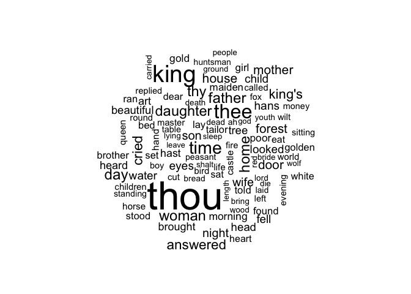

```r
wordcloud(wc_data$word, wc_data$n, max.words = 100)
```

### Step 6b: Zipf’s law

“Zipf’s law states that the frequency that a word appears is inversely proportional to its rank” (Pröllochs, n.d., p.24).

```r
term_freq <- tidy_book %>%
  count(word, sort = TRUE) %>%
  mutate(TotalWords = sum(n),
         rank = row_number(),
         tf = n / TotalWords)

# Let's see the result!
term_freq
```

```
## # A tibble: 8,265 x 5
##    word      n TotalWords  rank     tf
##    <chr> <int>      <int> <int>  <dbl>
##  1 the   20176     287329     1 0.0702
##  2 and   14740     287329     2 0.0513
##  3 to     7454     287329     3 0.0259
##  4 he     5955     287329     4 0.0207
##  5 a      5436     287329     5 0.0189
##  6 was    4173     287329     6 0.0145
##  7 it     4081     287329     7 0.0142
##  8 of     3858     287329     8 0.0134
##  9 in     3664     287329     9 0.0128
## 10 i      3320     287329    10 0.0116
## # … with 8,255 more rows
```

Then if you visualize this data…

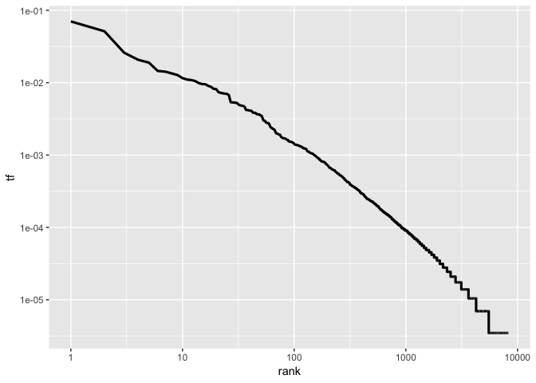

```r
term_freq %>%
  ggplot(aes(rank, tf)) +
  geom_line(size = 1.1, show.legend = FALSE) +
  scale_x_log10() +
  scale_y_log10()
```

# **Analysis Text Corpora** Example (Advanced)

"A text corpus is a **structured set of texts** (e. g. a collection of articles) (Pröllochs, n.d., p.26).

## Step 1: Load data - Physics classics

```r
gutenberg_metadata %>% filter(gutenberg_id %in% c(37729, 14725, 13476, 7333))
```

```
## # A tibble: 4 x 8
##   gutenberg_id title author gutenberg_autho… language gutenberg_books…
##          <int> <chr> <chr>             <int> <chr>    <chr>
## 1         7333 Side… Einst…             1630 en       <NA>
## 2        13476 "Exp… Tesla…             5067 en       <NA>
## 3        14725 "Tre… Huyge…             5648 en       <NA>
## 4        37729 A Di… Galil…            39014 en       <NA>
## # … with 2 more variables: rights <chr>, has_text <lgl>
```

```r
## Let's download this as a dataframe called `physics` ##
physics <- gutenberg_download(c(37729,14725,13476,7333), meta_fields = "author")
```

## Step 2: Data Exploration - Frequent words

```r
physics_words <- physics %>%
  unnest_tokens(word, text) %>%
  count(author, word, sort = TRUE) %>% print()
```

```
## # A tibble: 11,219 x 3
##    author              word      n
##    <chr>               <chr> <int>
##  1 Galilei, Galileo    the    3760
##  2 Tesla, Nikola       the    3604
##  3 Huygens, Christiaan the    3553
##  4 Galilei, Galileo    of     2049
##  5 Tesla, Nikola       of     1737
##  6 Huygens, Christiaan of     1708
##  7 Huygens, Christiaan to     1207
##  8 Tesla, Nikola       a      1176
##  9 Galilei, Galileo    and    1148
## 10 Galilei, Galileo    to     1133
## # … with 11,209 more rows
```

```r
# Then what if we're interested in what is the common word from each of these authors?
```

## Step 3: Understanding `Tf-idf` weighting concept

- Best known weighting scheme in **information retrieval**
- Increases with the number of **occurrences** of a term in a **document**
- Increases with the **rarity** of the term in the **collection**

> How to calculate `TF-idf`?
1. Term Frequency (*tf*): Number of times a term *t* occurs in a document *d*
2. Document Frequency (*df*): Number of documents *d* that contain each term *t*
3. Inverse Document Frequency: *`idf = log(N/df)`* where *N* is the total number of documents
4. Term frequency-inverse document frequency: *tf - idf = tf X idf*

## Step 4: Applying `Tf-idf` weighting

`bind_tf_idf(tbl, term, document, n)` adds tf-idf values to a tidy text dataset

**Code Structure**

- `tbl` is a tidy text dataset with one-row-per-term-per-document
- `term` is the column containing the terms (`word` in this case)
- `document` is the column containing the document IDs (`author` in this case)
- `n` is the column containing document-term counts (`n` in this case)

```r
physics_words %>%
  bind_tf_idf(word, author, n) %>%
  arrange(desc(tf_idf))
```

```
## # A tibble: 11,219 x 6
##    author              word           n      tf   idf  tf_idf
##    <chr>               <chr>      <int>   <dbl> <dbl>   <dbl>
##  1 Huygens, Christiaan refraction   218 0.00569 1.39  0.00789
##  2 Tesla, Nikola       bulb         171 0.00433 1.39  0.00600
##  3 Galilei, Galileo    water        828 0.0206  0.288 0.00593
##  4 Tesla, Nikola       coil         166 0.00420 1.39  0.00583
##  5 Einstein, Albert    theory        67 0.00774 0.693 0.00536
##  6 Einstein, Albert    relativity    31 0.00358 1.39  0.00496
##  7 Huygens, Christiaan ray          136 0.00355 1.39  0.00492
##  8 Tesla, Nikola       wire         133 0.00337 1.39  0.00467
##  9 Galilei, Galileo    hath         132 0.00328 1.39  0.00455
## 10 Einstein, Albert    euclidean     27 0.00312 1.39  0.00432
## # … with 11,209 more rows
```

## Step 5: Visualizing the results: Top 5 characteristics words per author (`ggplot` package)

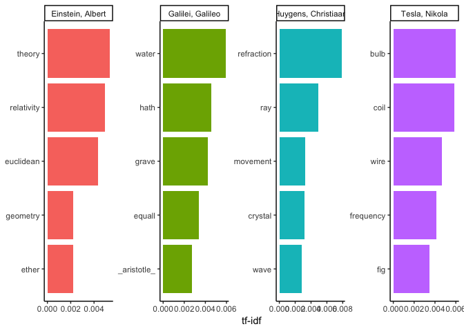

```r
plot_physics <- physics_words %>%
  bind_tf_idf(word, author, n) %>%
  group_by(author) %>%
  top_n(5, tf_idf) %>%
  ungroup()

ggplot(plot_physics, aes(reorder(word, tf_idf), tf_idf, fill = author)) +
  geom_col(show.legend = FALSE) + labs(x = NULL, y = "tf-idf") +
  facet_wrap( ~ author, ncol = 4, scales = "free") + coord_flip() + theme_classic()
```

# Next Steps

Can we replicate above processes to figure out…

> From July 2019 till now, can we visualize top 5 topics that our educators requested from Circle Time Magazine Qualtrics data sets by June 15, 2020?